Pular para o conteúdo principal

# Econometria III Atividade 6

Diferenças em Diferenças com R: Schiozer, Mourad e Martins (2021)

Autor

Prof. Dr. Washington S. da Silva

## Garantias Governamentais e Risco Bancário

O artigo de Schiozer, Mourad e Martins (2021), *A Tutorial on the Use of Differences-in-Differences in Management, Finance, and Accounting*, apresenta um guia prático para a utilização do método de **Diferenças em Diferenças (DiD)** em pesquisas que exploram *experimentos naturais* (ou *quase-experimentos*) para realizar inferência causal. Os autores discutem os fundamentos do estimador, suas vantagens, limitações e procedimentos de avaliação da validade dos resultados. Para ilustrar a aplicação do método, investigam como o aumento da percepção de garantias governamentais durante a crise financeira de 2008 afetou o risco bancário.

Durante crises financeiras, os governos frequentemente adotam medidas para preservar a estabilidade do sistema bancário. Algumas dessas medidas beneficiam o sistema como um todo, enquanto outras procuram evitar a falência de instituições consideradas sistemicamente importantes, muitas vezes denominadas *grandes demais para falir* (*too big to fail*).

A expectativa de que determinadas instituições financeiras receberão apoio governamental em caso de dificuldades constitui uma forma de **garantia governamental implícita**. Essa percepção pode influenciar o comportamento dos bancos, especialmente suas decisões relacionadas à exposição ao risco.

Entretanto, a teoria econômica não oferece uma previsão inequívoca sobre os efeitos dessas garantias. Conforme discutido por Schiozer, Mourad e Martins (2021), existem duas explicações concorrentes:

- **Hipótese do risco moral (*moral hazard*):** a expectativa de proteção governamental reduz os incentivos dos depositantes para monitorar os bancos, podendo estimular as instituições protegidas a assumir riscos maiores.
- **Hipótese do valor da franquia bancária (*charter value*):** a proteção governamental permite que os bancos obtenham financiamento a custos menores, criando um benefício econômico que as instituições desejam preservar. Nesse caso, a proteção pode incentivar um comportamento mais prudente e reduzir a exposição ao risco.

A crise financeira internacional de 2008 oferece uma oportunidade para investigar essas hipóteses. Durante a crise, o resgate de grandes instituições financeiras reforçou a percepção de que bancos sistemicamente importantes poderiam contar com apoio governamental, inclusive em países que não foram diretamente atingidos pela crise.

Nesse contexto, Schiozer, Mourad e Martins (2021) investigam a seguinte questão:

> **O aumento da percepção de garantias governamentais durante a crise financeira de 2008 levou os bancos protegidos a assumir mais ou menos risco?**

Para responder a essa pergunta, os autores utilizam a estratégia econométrica de **Diferenças em Diferenças (DiD)**, comparando a evolução do risco de bancos classificados como protegidos e não protegidos, antes e durante a crise financeira.

A comparação procura identificar se a mudança no risco dos bancos protegidos foi diferente daquela observada nos bancos não protegidos. Entretanto, sua interpretação causal depende de hipóteses de identificação, especialmente a de **tendências paralelas**, que examinaremos ao longo da atividade.

## Dados e desenho da pesquisa

### Amostra e estrutura dos dados

O artigo de Schiozer, Mourad e Martins (2021) utiliza informações financeiras e regulatórias de bancos pertencentes a 14 países-membros da Organização para a Cooperação e Desenvolvimento Econômico (OCDE), cujos sistemas bancários não foram diretamente afetados pela crise financeira internacional, segundo a classificação adotada pelos autores.

Essa seleção procura reduzir a possibilidade de que mudanças no risco bancário sejam explicadas pela exposição direta das instituições aos ativos que desencadearam a crise de 2008.

A amostra principal compreende o período de **2005 a 2010**, com **3.324 observações de 900 bancos**, organizadas em um painel não balanceado. Portanto, nem todos os bancos apresentam observações em todos os anos.

Os autores disponibilizaram a base/arquivo `RAC.dta`, que contém também dados dos anos de 2011 a 2013, utilizados em análises adicionais. Nesta atividade, trabalharemos com a amostra principal, correspondente ao período de 2005 a 2010.

### Medida do risco bancário

A variável dependente da pesquisa é baseada no **Z-score bancário**, um indicador amplamente utilizado na literatura financeira para avaliar a distância de uma instituição em relação à insolvência.

O indicador é definido por:

$$Z_{it} = \frac{ROA_{it} + Capital_{it}}{\sigma(ROA)_{it}},$$

em que:

- $ROA_{it}$ é o retorno sobre os ativos do banco $i$ no período $t$;
- $Capital_{it}$ é o índice de capital regulatório do banco;
- $\sigma(ROA)_{it}$ é o desvio-padrão do retorno sobre os ativos, calculado a partir dos três anos anteriores.

O Z-score relaciona a rentabilidade e a capitalização da instituição à volatilidade (desvio-padrão) de seus resultados. **Quanto menor o Z-score, maior o risco bancário**, pois menor é a distância estimada em relação à insolvência.

Os autores utilizam o logaritmo natural do Z-score, com tratamento dos valores extremos por winsorização a 1%. Na base disponibilizada, essa variável recebe o nome `w_ln_zScore`.

**DicaComo winsorizar o logaritmo do Z-score em R**

Nesta atividade, usamos diretamente `w_ln_zScore`, que já vem winsorizada no arquivo `RAC.dta`. O exemplo abaixo é apenas ilustrativo e parte de uma base hipotética, `dados_exemplo`, com a coluna `ln_zScore` contendo o logaritmo natural do Z-score antes da winsorização.

Uma forma de winsorizar a 1% em cada cauda é substituir valores abaixo do percentil 1 pelo próprio percentil 1 e valores acima do percentil 99 pelo próprio percentil 99. A operação preserva as linhas do objeto e os valores situados entre esses limites.

```r
# Calcula os percentis 1 e 99 usando os valores disponíveis do log do Z-score.
limites <- quantile(dados_exemplo$ln_zScore, probs = c(0.01, 0.99), na.rm = TRUE)

# Cria a coluna winsorizada e preserva a coluna original.
dados_winsor <- dados_exemplo |>
  dplyr::mutate(
    # pmax() eleva os valores abaixo do limite inferior.
    # pmin() reduz os valores acima do limite superior.
    w_ln_zScore = pmin(pmax(ln_zScore, limites[[1]]), limites[[2]])
  )
```

É importante observar que, como o Z-score apresenta uma relação inversa com o risco bancário, **uma redução do logaritmo do Z-score indica um aumento do risco**.

### Grupos de tratamento e controle

A estratégia de identificação utiliza a crise financeira internacional de 2008 como um choque que aumentou a percepção de garantias governamentais para determinados bancos.

A classificação dos bancos é baseada nas avaliações de uma agência de classificação de risco sobre a probabilidade de cada instituição receber apoio externo, utilizando as informações disponíveis antes da crise.

Os autores definem dois grupos:

- **Grupo de tratamento (`treated = 1`):** bancos classificados como passíveis de receber apoio externo, cuja percepção de proteção governamental teria aumentado durante a crise.
- **Grupo de controle (`treated = 0`):** bancos sem expectativa de apoio externo na classificação utilizada, para os quais a percepção de proteção teria se alterado relativamente pouco.

Essa classificação não significa que os bancos tratados tenham efetivamente recebido recursos governamentais. O mecanismo investigado é a **mudança na percepção de proteção**, e não o recebimento de um resgate financeiro.

### Períodos anterior e posterior ao choque

A pesquisa divide o período de análise em dois intervalos:

- **Antes da crise (`crisis = 0`):** 2005, 2006 e 2007.
- **Durante a crise (`crisis = 1`):** 2008, 2009 e 2010.

Combinando a classificação dos bancos e os dois períodos, obtemos as quatro situações necessárias para construir o estimador de Diferenças em Diferenças:

| Grupo | Antes da crise (2005–2007) | Durante a crise (2008–2010) |
| --- | --- | --- |
| Bancos não protegidos | Controle, antes | Controle, durante |
| Bancos protegidos | Tratamento, antes | Tratamento, durante |

O objetivo da DiD é comparar a variação média do logaritmo do Z-score dos bancos protegidos com a variação média observada nos bancos não protegidos.

Essa comparação procura identificar o efeito diferencial associado ao aumento da percepção de garantias governamentais.

Entretanto, para interpretar essa diferença como um efeito causal, precisamos admitir que, **na ausência da mudança diferencial na percepção de proteção, os dois grupos teriam apresentado tendências paralelas na evolução do risco bancário**.

Essa hipótese será fundamental para interpretar os resultados da análise empírica.

## Exploração dos dados em R

### Seleção da amostra

O arquivo `RAC.dta`, já importado para o objeto `dados_did`, contém 5.808 observações referentes ao período de 2005 a 2013.

Para reproduzir a aplicação principal de Schiozer, Mourad e Martins (2021), utilizaremos apenas as observações de **2005 a 2010**. Inicialmente, selecionaremos as cinco variáveis necessárias à nossa análise:

- `indexNumber`: identificador do banco;
- `year`: ano da observação;
- `treated`: indicador de pertencimento ao grupo de tratamento;
- `crisis`: indicador do período da crise financeira;
- `w_ln_zScore`: logaritmo natural do Z-score bancário, com tratamento dos valores extremos.

```r
# Filtra e organiza a amostra usada em toda a análise DiD.
amostra_did <- dados_did |>
  # between filtra os anos no intervalo [2005, 2010]
  filter(between(year, 2005, 2010)) |>
  # Seleciona apenas as variáveis usadas na atividade.
  select(indexNumber, year, treated, crisis, w_ln_zScore) |>
  # Ordena por banco e ano.
  arrange(indexNumber, year)

# Exibe estrutura, tipos e valores de referência.
glimpse(amostra_did)
```

```
Rows: 3,324
Columns: 5
$ indexNumber <dbl> 10233, 10233, 10582, 11622, 11622, 11622, 11907, 11907, 12…
$ year        <dbl> 2009, 2010, 2009, 2008, 2009, 2010, 2009, 2010, 2008, 2009…
$ treated     <dbl> 0, 0, 0, 0, 0, 0, 0, 0, 0, 0, 1, 1, 1, 1, 1, 0, 0, 0, 0, 0…
$ crisis      <dbl> 1, 1, 1, 1, 1, 1, 1, 1, 1, 1, 0, 0, 1, 1, 1, 1, 1, 1, 0, 0…
$ w_ln_zScore <dbl> 2.1649, 2.1055, 3.0172, 3.5369, 3.4412, 2.4515, 3.7168, 3.…
```

A função `between()` seleciona as observações cujos anos estão entre 2005 e 2010, incluindo os dois limites. Em seguida, `select()` mantém apenas as variáveis que utilizaremos, enquanto `arrange()` organiza os registros por banco e ano.

### Estrutura do painel

Vamos verificar as dimensões da amostra, identificando a quantidade de observações, bancos e anos disponíveis.

```r
# Resume a cobertura total da amostra.
amostra_did |>
  summarise(
    # n() conta linhas.
    observacoes = n(),
    # n_distinct() conta bancos únicos.
    bancos = n_distinct(indexNumber),
    # Conta anos distintos representados.
    anos = n_distinct(year)
  )
```

```
# A tibble: 1 × 3
  observacoes bancos  anos
        <int>  <int> <int>
1        3324    900     6
```

A amostra contém **3.324 observações de 900 bancos**, distribuídas entre 2005 e 2010.

Cada observação corresponde a uma combinação entre banco e ano. Entretanto, como o painel é não balanceado, nem todos os bancos apresentam informações nos seis anos.

Podemos examinar como as observações estão distribuídas ao longo do tempo.

```r
# Conta observações por ano para comparar a cobertura temporal.
amostra_did |>
  count(year, name = "observacoes")
```

```
# A tibble: 6 × 2
   year observacoes
  <dbl>       <int>
1  2005         216
2  2006         258
3  2007         334
4  2008         835
5  2009         844
6  2010         837
```

O número de observações aumenta consideravelmente a partir de 2008. Em 2007, temos 334 observações, enquanto em 2008 esse número alcança 835.

Para compreender melhor o desbalanceamento, vamos contar quantos anos estão disponíveis para cada banco.

```r
periodos_banco <- amostra_did |>
  # Conta quantos anos cada banco aparece na amostra.
  count(indexNumber, name = "n_anos") |>
  # Resume a distribuição: quantos bancos têm 1, 2, ..., n anos.
  count(n_anos, name = "bancos")

# Exibe a distribuição final de períodos por banco.
periodos_banco
```

```
# A tibble: 6 × 2
  n_anos bancos
   <int>  <int>
1      1     31
2      2     45
3      3    509
4      4     81
5      5     52
6      6    182
```

Os resultados mostram que apenas **182 bancos possuem observações em todos os seis anos**. Os demais apresentam informações para um número menor de períodos.

Portanto, a amostra não corresponde a um conjunto fixo de 900 bancos acompanhados continuamente de 2005 a 2010.

### Distribuição entre tratamento e controle

Na estratégia de DiD, precisamos identificar as observações dos bancos protegidos e não protegidos, antes e durante a crise.

As variáveis `treated` e `crisis` permitem construir essas quatro combinações.

```r
# Compara cobertura entre grupos e períodos.
amostra_did |>
  # Agrupa por tratamento e período da crise.
  group_by(treated, crisis) |>
  # Resume cada combinação em uma linha.
  summarise(
    # Conta observações banco-ano.
    observacoes = n(),
    # Conta bancos únicos em cada combinação.
    bancos = n_distinct(indexNumber)
  )
```

```
# A tibble: 4 × 4
# Groups:   treated [2]
  treated crisis observacoes bancos
    <dbl>  <dbl>       <int>  <int>
1       0      0         490    227
2       0      1        2102    731
3       1      0         318    125
4       1      1         414    143
```

Lembre-se de que `treated = 1` identifica os bancos protegidos, enquanto `crisis = 1` corresponde aos anos de 2008 a 2010.

Os resultados mostram:

| Grupo | Antes da crise | Durante a crise |
| --- | --- | --- |
| Bancos não protegidos | 490 | 2.102 |
| Bancos protegidos | 318 | 414 |
| **Total** | **808** | **2.516** |

Os valores representam **observações banco–ano**, e não bancos distintos. Um mesmo banco pode contribuir com observações em diferentes anos.

Observe que a distribuição da amostra muda substancialmente entre os períodos. O número de observações dos bancos não protegidos, em particular, é muito maior durante a crise.

### Composição da amostra ao longo do tempo

Uma questão importante em aplicações de DiD é verificar se as mesmas unidades são observadas antes e depois do tratamento.

Para isso, vamos identificar quais bancos possuem pelo menos uma observação anterior à crise e pelo menos uma observação durante a crise.

```r
# Gera, por banco, flags de presença no pré-crise e na crise.
presenca_bancos <- amostra_did |>
  # Agrupa observações de cada banco para avaliar presença por período.
  group_by(indexNumber) |>
  summarise(
    # any() verifica se existe pelo menos uma linha do banco no pré-crise.
    antes = any(crisis == 0),
    # any() verifica se existe pelo menos uma linha do banco na crise.
    durante = any(crisis == 1)
  )

# Conta bancos em cada combinação de presença (antes × durante).
presenca_bancos |>
  count(antes, durante, name = "bancos")
```

```
# A tibble: 3 × 3
  antes durante bancos
  <lgl> <lgl>    <int>
1 FALSE TRUE       548
2 TRUE  FALSE       26
3 TRUE  TRUE       326
```

A função `any()` verifica se pelo menos uma observação de cada banco satisfaz a condição indicada. Os valores `TRUE` e `FALSE` informam, respectivamente, se o banco está presente ou ausente em cada período.

Encontramos:

- **326 bancos** observados antes e durante a crise;
- **26 bancos** observados somente antes da crise;
- **548 bancos** observados somente durante a crise.

Esse resultado merece atenção: dos 900 bancos da amostra, apenas 326 aparecem nos dois períodos.

Consequentemente, as mudanças observadas nas médias dos grupos podem refletir tanto alterações no risco bancário quanto **mudanças na composição das instituições observadas**.

Essa característica não invalida automaticamente o método DiD, mas representa uma limitação importante para a interpretação dos resultados. Retomaremos essa questão ao comparar as especificações econométricas.

### Evolução do risco bancário

Antes de estimar o modelo DiD, é importante examinar graficamente a evolução da variável dependente nos grupos de tratamento e controle.

Seguindo a análise descritiva de Schiozer, Mourad e Martins (2021), calcularemos a média anual do logaritmo do Z-score para cada grupo.

```r
# Calcula médias anuais para o gráfico de tendências.
medias_anuais <- amostra_did |>
  # Agrupa por ano e condição de proteção.
  group_by(year, treated) |>
  # Resume cada combinação em uma linha.
  summarise(
    # Calcula a média do log do Z-score.
    media_ln_z = mean(w_ln_zScore),
    # Registra o tamanho amostral em cada célula.
    observacoes = n()
  ) |>
  # Codifica `treated = 1` como "Protegidos" e
  # `treated = 0` como "Não protegidos" em grupo.
  mutate(
    grupo = if_else(treated == 1, "Protegidos", "Não protegidos")
  )

# Exibe médias e tamanhos amostrais por ano e grupo.
medias_anuais
```

```
# A tibble: 12 × 5
# Groups:   year [6]
    year treated media_ln_z observacoes grupo
   <dbl>   <dbl>      <dbl>       <int> <chr>
 1  2005       0       4.63         125 Não protegidos
 2  2005       1       4.57          91 Protegidos
 3  2006       0       4.57         152 Não protegidos
 4  2006       1       4.62         106 Protegidos
 5  2007       0       4.47         213 Não protegidos
 6  2007       1       4.65         121 Protegidos
 7  2008       0       3.99         698 Não protegidos
 8  2008       1       3.82         137 Protegidos
 9  2009       0       4.18         706 Não protegidos
10  2009       1       3.84         138 Protegidos
11  2010       0       4.35         698 Não protegidos
12  2010       1       4.15         139 Protegidos
```

A tabela apresenta, para cada ano, o valor médio da variável dependente e a quantidade de observações utilizadas em seu cálculo.

Agora, utilizaremos o `ggplot2` para visualizar essas trajetórias.

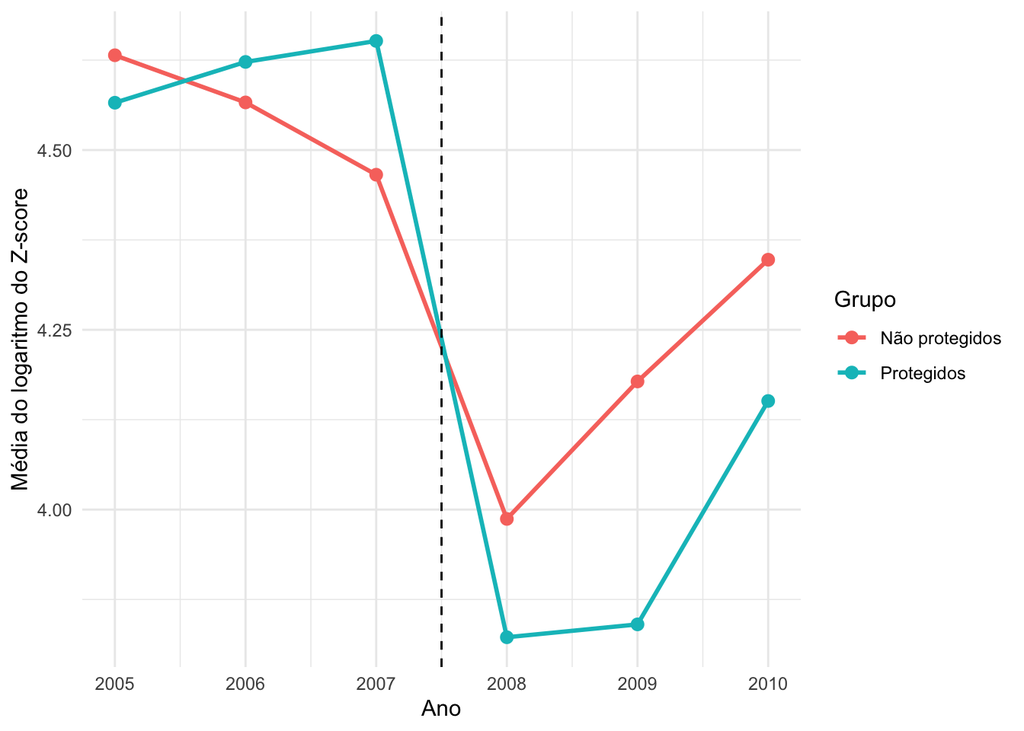

Figura 1: Evolução da média anual do logaritmo do Z-score dos bancos protegidos e não protegidos (2005–2010). A linha tracejada separa os períodos anterior e posterior ao início da crise financeira.

```r
# Plota a trajetória média dos dois grupos ao longo do tempo.
ggplot(
  # Usa a tibble de médias anuais.
  medias_anuais,
  # Define eixos e cor por grupo.
  aes(x = year, y = media_ln_z, color = grupo)
) +
  # Cria linha que liga os pontos anuais de cada grupo.
  geom_line(linewidth = 1) +
  # Define o tamanho do ponto
  geom_point(size = 2.5) +
  # Cria reta vertical que marca a transição entre pré-crise e crise.
  geom_vline(xintercept = 2007.5, linetype = "dashed") +
  # Define os anos mostrados no eixo x.
  scale_x_continuous(breaks = 2005:2010) +
  # Define rótulos dos eixos e da legenda.
  labs(
    x = "Ano",
    y = "Média do logaritmo do Z-score",
    color = "Grupo"
  ) +
  # Usa tema limpo para leitura rápida.
  theme_minimal()
```

A Figura 1 apresenta uma adaptação didática da Figura 2 de Schiozer, Mourad e Martins (2021), utilizando linhas para representar a evolução das médias anuais dos dois grupos. A linha vertical tracejada separa o período anterior à crise (2005–2007) do período da crise (2008–2010).

Observe que:

1. **Antes da crise**, as trajetórias médias dos grupos apresentam comportamentos distintos. O logaritmo do Z-score aumenta entre os bancos protegidos e diminui entre os não protegidos. As linhas se cruzam entre 2005 e 2006, e a diferença entre as médias aumenta até 2007.
2. **Em 2008**, ocorre uma queda acentuada do logaritmo do Z-score nos dois grupos, mais intensa entre os bancos protegidos. Como o Z-score varia inversamente com o risco, essa redução corresponde a um aumento do risco bancário.
3. **Em 2009 e 2010**, as médias apresentam recuperação parcial, mas permanecem inferiores aos níveis anteriores à crise.

**DicaTendências antes da crise: atividade e artigo**

As médias desta atividade reproduzem as da Figura 2 de Schiozer, Mourad e Martins (2021), mas o gráfico utiliza linhas para ligar os pontos, destacando diferenças entre as trajetórias antes da crise. Os autores, por sua vez, consideram essas tendências **aproximadamente paralelas** e, em análise adicional apresentada na Figura 3, não rejeitam a hipótese de tendências paralelas no período anterior à crise.

Portanto, **não há diferença nos dados**, mas uma diferença de ênfase na leitura do gráfico. A inspeção visual, isoladamente, não comprova nem refuta a hipótese de identificação.

Além disso, como verificamos anteriormente, a composição da amostra varia consideravelmente entre os anos. Portanto, as trajetórias representam médias das instituições observadas em cada período, e não necessariamente a evolução das mesmas instituições ao longo de todo o intervalo.

Na próxima seção, utilizaremos essas informações para construir o estimador de Diferenças em Diferenças e compreender sua interpretação econométrica.

## Construção e estimação do estimador DiD

Na seção anterior, verificamos que o logaritmo do Z-score diminuiu durante a crise financeira tanto entre os bancos protegidos quanto entre os não protegidos.

Entretanto, uma redução mais acentuada entre os bancos protegidos não é, isoladamente, suficiente para identificar o efeito associado ao aumento da percepção de garantias governamentais.

O estimador de **Diferenças em Diferenças (DiD)** procura separar a mudança observada nos bancos protegidos daquela que também ocorreu nos bancos do grupo de controle.

### Cálculo da dupla diferença

O estimador DiD é construído em duas etapas:

1. Calculamos a diferença entre as médias dos períodos anterior e posterior ao choque, separadamente para cada grupo.
2. Subtraímos a variação do grupo de controle da variação do grupo de tratamento.

Formalmente:

$$\widehat{\delta}_{DiD}
=
\left(\overline{Y}_{1,1}-\overline{Y}_{1,0}\right)
-
\left(\overline{Y}_{0,1}-\overline{Y}_{0,0}\right),$$

em que $\overline{Y}_{g,p}$ representa a média do logaritmo do Z-score no grupo $g$ e no período $p$. O primeiro índice identifica o grupo (1 = protegido; 0 = não protegido), e o segundo identifica o período (1 = durante a crise; 0 = antes da crise).

Começaremos calculando as quatro médias necessárias.

```r
# Calcula as quatro médias que entram na DiD.
medias_did <- amostra_did |>
  # Agrupa por tratamento e período.
  group_by(treated, crisis) |>
  # Calcula a média em cada célula do desenho DiD.
  summarise(
    media_ln_z = mean(w_ln_zScore)
  )

# Exibe as quatro médias da DiD.
medias_did
```

```
# A tibble: 4 × 3
# Groups:   treated [2]
  treated crisis media_ln_z
    <dbl>  <dbl>      <dbl>
1       0      0       4.54
2       0      1       4.17
3       1      0       4.62
4       1      1       3.94
```

As médias são calculadas utilizando todas as observações banco–ano disponíveis em cada combinação de grupo e período, como na especificação básica dos autores.

Para facilitar a comparação, vamos organizar os resultados em uma tabela que apresente os dois períodos lado a lado e calcule a variação de cada grupo.

```r
# Reorganiza médias para comparar períodos dentro de cada grupo.
tabela_did <- medias_did |>
  # Converte indicadores em rótulos legíveis.
  mutate(
    # Codifica `treated = 1` como "Protegidos" e `treated = 0` como "Não protegidos".
    grupo = if_else(treated == 1, "Protegidos", "Não protegidos"),
    # Codifica `crisis = 1` como "Durante" e `crisis = 0` como "Antes".
    periodo = if_else(crisis == 1, "Durante", "Antes")
  ) |>
  # pivot_wider() transforma valores de `periodo` em colunas.
  pivot_wider(
    # Mantém uma linha por grupo.
    id_cols = grupo,
    # Usa períodos como nomes de coluna.
    names_from = periodo,
    # Preenche com as médias calculadas.
    values_from = media_ln_z
  ) |>
  # Calcula a variação dentro de cada grupo.
  mutate(
    variacao = Durante - Antes
  )

# Exibe médias antes/depois e variação por grupo.
tabela_did
```

```
# A tibble: 2 × 4
  grupo          Antes Durante variacao
  <chr>          <dbl>   <dbl>    <dbl>
1 Não protegidos  4.54    4.17   -0.368
2 Protegidos      4.62    3.94   -0.679
```

A função `pivot_wider()` transforma os períodos em colunas, permitindo comparar diretamente as médias anteriores e posteriores à crise.

Os resultados são:

| Grupo | Antes da crise | Durante a crise | Variação |
| --- | --- | --- | --- |
| Não protegidos | 4,5392 | 4,1709 | -0,3683 |
| Protegidos | 4,6173 | 3,9387 | -0,6786 |

O logaritmo médio do Z-score diminuiu **0,6786 ponto entre os bancos protegidos** e **0,3683 ponto entre os não protegidos**.

A dupla diferença corresponde à diferença entre essas duas variações:

$$\begin{aligned}
\widehat{\delta}_{DiD}
&= (-0{,}6786)-(-0{,}3683)\\
&\approx \boxed{-0{,}3103}.
\end{aligned}$$

Podemos obter esse resultado diretamente em R.

```r
# Obtém a DiD diretamente das variações dos grupos.
did_manual <- tabela_did |>
  # Seleciona apenas grupo e variação.
  select(grupo, variacao) |>
  # Coloca as duas variações na mesma linha.
  pivot_wider(
    # Cria uma coluna para cada grupo.
    names_from = grupo,
    # Preenche com a variação de cada grupo.
    values_from = variacao
  ) |>
  # Calcula a dupla diferença: tratado menos controle.
  mutate(
    did = Protegidos - `Não protegidos`
  ) |>
  # pull() extrai o valor numérico final da coluna `did`.
  pull(did)

# Exibe a estimativa manual da DiD.
did_manual
```

```
[1] -0.3103
```

O resultado indica que, entre os períodos anterior e posterior ao início da crise, **o logaritmo do Z-score dos bancos protegidos diminuiu aproximadamente 0,3103 ponto a mais do que o dos bancos não protegidos**.

Como valores menores do Z-score indicam maior risco, o sinal negativo da estimativa é compatível com a **hipótese do risco moral**: a percepção de proteção governamental poderia incentivar os bancos a assumir riscos maiores.

Entretanto, esse resultado ainda representa uma comparação descritiva entre as mudanças observadas nos dois grupos. Sua interpretação como efeito causal depende das hipóteses de identificação da DiD, especialmente a de tendências paralelas.

### Estimação da DiD por regressão

O mesmo estimador pode ser obtido por meio de uma regressão linear, combinando os indicadores de tratamento e de período.

Seguindo Schiozer, Mourad e Martins (2021), consideramos o modelo:

$$Y_{it}
=
\beta_0
+
\beta_1 Crisis_t
+
\beta_2 Treated_i
+
\beta_3 (Crisis_t \times Treated_i)
+
u_{it},$$

em que $Y_{it}$ representa o logaritmo do Z-score do banco $i$ no ano $t$.

Os coeficientes possuem as seguintes interpretações:

- **$\beta_0$:** média do logaritmo do Z-score dos bancos não protegidos antes da crise.
- **$\beta_1$:** mudança média do logaritmo do Z-score dos bancos não protegidos entre os dois períodos.
- **$\beta_2$:** diferença entre as médias dos bancos protegidos e não protegidos antes da crise.
- **$\beta_3$:** diferença entre as mudanças médias dos dois grupos, isto é, o **estimador DiD**.

O coeficiente de interesse é, portanto, $\beta_3$, associado à interação entre `crisis` e `treated`.

Estimaremos esse modelo utilizando a função `feols()` do pacote `fixest`. Diferentemente da implementação original dos autores, que utiliza `felm()`, adotaremos `feols()` por já fazer parte do conjunto de ferramentas utilizado nesta atividade. A especificação econométrica permanece a mesma.

```r
# Estima a DiD via regressão linear.
modelo_did <- feols(
  # Inclui período, tratamento e interação.
  w_ln_zScore ~ crisis + treated + crisis:treated,
  # Usa a mesma amostra da etapa descritiva.
  data = amostra_did,
  # Agrupa erros-padrão por banco.
  vcov = ~indexNumber
)

# Exibe coeficientes, erros-padrão e ajuste do modelo.
summary(modelo_did)
```

```
OLS estimation, Dep. Var.: w_ln_zScore
Observations: 3,324
Standard-errors: Clustered (indexNumber)
               Estimate Std. Error  t value    Pr(>|t|)
(Intercept)     4.53919   0.075047 60.48441   < 2.2e-16 ***
crisis         -0.36828   0.085158 -4.32465 0.000016987 ***
treated         0.07814   0.122520  0.63778 0.523781013
crisis:treated -0.31030   0.128855 -2.40815 0.016234057 *
---
Signif. codes:  0 '***' 0.001 '**' 0.01 '*' 0.05 '.' 0.1 ' ' 1
RMSE: 1.34026   Adj. R2: 0.021505
```

Na fórmula do modelo, `crisis` representa o indicador do período, `treated` identifica os bancos protegidos e `crisis:treated` representa a interação entre as duas variáveis. O operador `:` é utilizado no R para especificar explicitamente essa interação.

A opção `vcov = ~indexNumber` solicita **erros-padrão agrupados no nível dos bancos**. Esse procedimento considera que as observações de um mesmo banco podem apresentar correlação ao longo do tempo.

Esse cuidado é importante para a inferência estatística em dados em painel, pois tratar todas as observações banco–ano como independentes poderia produzir erros-padrão inadequados.

### Interpretação dos resultados da regressão

A estimação utiliza **3.324 observações de 900 bancos** e produz, aproximadamente, os seguintes coeficientes:

| Variável | Coeficiente estimado |
| --- | --- |
| Intercepto | 4,5392 |
| `crisis` | -0,3683 |
| `treated` | 0,0781 |
| `crisis:treated` | **-0,3103** |

Observe que o coeficiente da interação é exatamente o mesmo valor obtido pelo cálculo da dupla diferença.

Podemos verificar essa equivalência em R.

```r
# Compara a DiD manual com o coeficiente da regressão.
c(
  # Valor obtido pela dupla diferença das médias.
  calculo_manual = did_manual,
  # Coeficiente da interação (estimativa DiD na regressão).
  regressao = coef(modelo_did)[["crisis:treated"]]
)
```

```
calculo_manual      regressao
       -0.3103        -0.3103
```

Essa equivalência não é uma coincidência: no modelo DiD básico com dois grupos e dois períodos, a regressão linear com a interação reproduz a diferença entre as mudanças médias dos grupos.

A vantagem da estimação por regressão é permitir, além da obtenção do coeficiente DiD, a realização de **inferência estatística**.

Na coluna 1 da Tabela 2 de Schiozer, Mourad e Martins (2021), o coeficiente estimado para a interação é aproximadamente **-0,3103**, com **erro-padrão de 0,1289**, agrupado por banco.

O valor-p é de aproximadamente **0,016**, indicando que rejeitamos a hipótese nula $H_0:\beta_3=0$ ao nível de significância de 5%.

Portanto, a regressão apresenta evidência estatística de uma mudança diferencial negativa no logaritmo do Z-score dos bancos protegidos durante a crise.

Entretanto, **significância estatística não garante identificação causal**.

A inspeção da Figura 1, isoladamente, não verifica a hipótese de tendências paralelas. Além disso, a composição da amostra muda substancialmente entre os períodos. Essas características exigem cautela antes de atribuir a diferença estimada exclusivamente ao aumento da percepção de garantias governamentais.

Na próxima seção, examinaremos especificações com **efeitos fixos**, que permitem controlar características não observadas dos bancos que permanecem constantes ao longo do tempo, além de efeitos comuns dos anos.

## DiD com efeitos fixos

Na seção anterior, estimamos o modelo DiD básico e encontramos um coeficiente de aproximadamente **-0,3103** para a interação entre os indicadores de crise e tratamento.

Entretanto, essa especificação não controla explicitamente as características dos bancos que podem influenciar seu risco.

Por exemplo, bancos protegidos e não protegidos podem diferir em aspectos como modelo de negócios, estrutura organizacional e políticas de gestão de risco.

Quando essas características estão associadas tanto à classificação dos bancos quanto à variável dependente, sua omissão pode comprometer a interpretação dos resultados.

Uma alternativa é incorporar **efeitos fixos**, explorando a estrutura em painel dos dados.

### Efeitos fixos dos bancos

O modelo com efeitos fixos de banco permite controlar características observadas e não observadas de cada instituição que permanecem constantes ao longo do período analisado.

A especificação correspondente à coluna 5 da Tabela 2 de Schiozer, Mourad e Martins (2021) é:

$$Y_{it}
=
\alpha_i
+
\beta_1 Crisis_t
+
\beta_3(Crisis_t \times Treated_i)
+
u_{it},$$

em que $\alpha_i$ representa o efeito fixo do banco $i$.

Observe que a variável $Treated_i$ não aparece isoladamente na equação. Como a classificação de tratamento permanece constante para cada banco, seu efeito é **perfeitamente colinear com os efeitos fixos individuais** e, portanto, não pode ser estimado separadamente.

O coeficiente de interesse continua sendo $\beta_3$, associado à interação entre tratamento e período.

Antes da estimação, seguiremos o procedimento dos autores e excluiremos os bancos que possuem somente uma observação na amostra. Essas instituições não contribuem para a identificação dos coeficientes em uma regressão com efeitos fixos individuais.

```r
# Cria amostra para modelos com efeitos fixos de banco.
amostra_fe <- amostra_did |>
  # Agrupa por banco para contar linhas por unidade.
  group_by(indexNumber) |>
  # Mantém apenas bancos com pelo menos duas observações (n() > 1).
  filter(n() > 1) |>
  # Remove o agrupamento para os resumos seguintes.
  ungroup()

# Resume o tamanho da amostra após o filtro.
amostra_fe |>
  summarise(
    # Conta observações restantes.
    observacoes = n(),
    # Conta bancos únicos restantes.
    bancos = n_distinct(indexNumber)
  )
```

```
# A tibble: 1 × 2
  observacoes bancos
        <int>  <int>
1        3293    869
```

A amostra passa de 3.324 para **3.293 observações**, distribuídas entre **869 bancos**. Portanto, foram excluídas 31 instituições com apenas uma observação.

Agora, estimaremos o modelo com efeitos fixos individuais.

```r
# Estima a DiD com efeitos fixos de banco.
modelo_fe_banco <- feols(
  # Inclui período, interação e efeito fixo por banco.
  w_ln_zScore ~ crisis + crisis:treated | indexNumber,
  # Usa a amostra filtrada para efeitos fixos.
  data = amostra_fe,
  # Agrupa erros-padrão por banco.
  vcov = ~indexNumber,
  # Ajusta graus de liberdade contando parâmetros dos efeitos fixos.
  ssc = ssc(K.fixef = "full")
)

# Exibe coeficientes, erros-padrão e ajuste do modelo.
summary(modelo_fe_banco)
```

```
OLS estimation, Dep. Var.: w_ln_zScore
Observations: 3,293
Fixed-effects: indexNumber: 869
Standard-errors: Clustered (indexNumber)
                Estimate Std. Error  t value        Pr(>|t|)
crisis         -0.585967   0.099708 -5.87682 0.0000000059584 ***
crisis:treated -0.084033   0.151940 -0.55307 0.5803613431674
---
Signif. codes:  0 '***' 0.001 '**' 0.01 '*' 0.05 '.' 0.1 ' ' 1
RMSE: 0.657395     Adj. R2: 0.678581
                 Within R2: 0.098539
```

Na função `feols()`, o símbolo `|` separa os regressores dos efeitos fixos. Assim, `indexNumber` indica que devemos incorporar um efeito fixo para cada banco.

A opção `ssc(K.fixef = "full")` determina que os parâmetros dos efeitos fixos sejam contabilizados na correção dos erros-padrão para os graus de liberdade, permitindo reproduzir o procedimento inferencial utilizado pelos autores.

A estimativa do coeficiente `crisis:treated` é de aproximadamente **-0,0840**, com erro-padrão de **0,1519**.

Embora o coeficiente permaneça negativo, sua magnitude é consideravelmente menor do que a estimada no modelo básico (-0,3103).

Além disso, o coeficiente deixa de ser estatisticamente significativo ao nível de 5%.

Portanto, **a evidência de uma mudança diferencial no risco bancário torna-se menos convincente quando incorporamos os efeitos fixos de banco**, que controlam a heterogeneidade individual não observada, suposta constante no tempo.

### Efeitos fixos dos bancos e dos anos

O modelo anterior controla a heterogeneidade individual não observada, suposta constante no tempo, mas ainda utiliza apenas o indicador `crisis` para representar mudanças comuns entre os períodos.

Entretanto, outros acontecimentos podem afetar o risco bancário em determinados anos, independentemente da proteção governamental.

Os **efeitos fixos de ano** permitem controlar fatores comuns a todos os bancos em cada ano, como mudanças macroeconômicas e regulatórias.

A especificação com efeitos fixos de banco e ano, correspondente à coluna 6 da Tabela 2 de Schiozer, Mourad e Martins (2021), é conhecida como **DiD generalizado**:

$$Y_{it}
=
\alpha_i
+
\lambda_t
+
\beta_3(Crisis_t \times Treated_i)
+
u_{it},$$

em que:

- $\alpha_i$ representa os efeitos fixos dos bancos;
- $\lambda_t$ representa os efeitos fixos dos anos;
- $\beta_3$ é o coeficiente DiD de interesse.

Nessa especificação, o indicador `treated` é absorvido pelos efeitos fixos de banco, enquanto o indicador `crisis` é absorvido pelos efeitos fixos de ano.

Por isso, **apenas a interação entre tratamento e período precisa aparecer explicitamente entre os regressores**.

```r
# Estima a DiD com efeitos fixos de banco e ano.
modelo_fe_bidirecional <- feols(
  # Inclui interação e efeitos fixos bidirecionais.
  w_ln_zScore ~ crisis:treated | indexNumber + year,
  # Usa a mesma amostra do modelo com FE de banco.
  data = amostra_fe,
  # Mantém erros-padrão agrupados por banco.
  vcov = ~indexNumber,
  # Ajusta graus de liberdade pelos parâmetros de FE.
  ssc = ssc(K.fixef = "full")
)

# Exibe coeficiente da interação, erro-padrão e ajuste.
summary(modelo_fe_bidirecional)
```

```
OLS estimation, Dep. Var.: w_ln_zScore
Observations: 3,293
Fixed-effects: indexNumber: 869,  year: 6
Standard-errors: Clustered (indexNumber)
                Estimate Std. Error  t value Pr(>|t|)
crisis:treated -0.077548    0.15345 -0.50537  0.61343
---
Signif. codes:  0 '***' 0.001 '**' 0.01 '*' 0.05 '.' 0.1 ' ' 1
RMSE: 0.644679     Adj. R2: 0.690383
                 Within R2: 4.24e-4
```

Observe que a expressão `indexNumber + year`, após o símbolo `|`, indica a inclusão simultânea de efeitos fixos dos bancos e dos anos.

O coeficiente estimado para `crisis:treated` é de aproximadamente **-0,0775**, com erro-padrão de **0,1534**.

Assim como na especificação anterior, a estimativa permanece negativa, mas **não é estatisticamente significativa ao nível de 5%**.

O resultado indica que, após incorporar os efeitos fixos dos bancos e dos anos, não encontramos evidência estatística suficiente para rejeitar a hipótese de ausência de mudança diferencial no logaritmo do Z-score dos bancos protegidos.

### Comparação das especificações

Para comparar os três modelos, utilizaremos a função `etable()` do pacote `fixest`.

Essa função reúne os resultados das regressões em uma única tabela, facilitando a comparação dos coeficientes, erros-padrão e medidas de ajuste.

```r
# Define os três modelos comparados no data frame final.
modelos <- list(
  "(1) DiD básico" = modelo_did,
  "(5) EF de banco" = modelo_fe_banco,
  "(6) EF de banco e ano" = modelo_fe_bidirecional
)

# Define rótulos de linhas para o data frame.
rotulos <- c(
  # Rótulos dos coeficientes principais.
  "(Intercept)" = "Constante",
  "crisis" = "Período de crise",
  "treated" = "Banco protegido",
  "crisis:treated" = "Crise × banco protegido",
  # Rótulos das dimensões de efeitos fixos.
  "indexNumber" = "Efeitos fixos de banco",
  "year" = "Efeitos fixos de ano",
  # Rótulos das estatísticas de ajuste.
  "n" = "Observações",
  "r2" = "R²",
  "wr2" = "R² within"
)

# Gera um data frame-resumo dos modelos.
tabela <- fixest::etable(
  # Define modelos e ordem das colunas.
  modelos,
  # Usa os erros-padrão já embutidos em cada modelo.
  vcov = NULL,
  # Mantém saída em objeto data frame (não LaTeX).
  tex = FALSE,
  # Desativa formatação markdown interna.
  markdown = FALSE,
  # Aplica os rótulos definidos acima.
  dict = rotulos,
  # Exibe coeficientes e erros com quatro casas.
  digits = "r4",
  # Exibe estatísticas com quatro casas.
  digits.stats = "r4",
  # Remove estrelas de significância.
  signif.code = NA,
  # Mostra erro-padrão na mesma linha do coeficiente.
  se.below = FALSE,
  # Oculta cabeçalho da variável dependente (já informado no texto).
  depvar = FALSE,
  # Oculta linha extra sobre erros-padrão (já informada na nota).
  se.row = FALSE,
  # Inclui observações, R² total e R² within.
  fitstat = ~ n + r2 + wr2,
  # Ajusta rótulos visuais para saída HTML.
  style.df = fixest::style.df(
    # Indica presença de efeitos fixos como Sim/Não.
    yesNo = c("Sim", "Não"),
    # Remove títulos/separadores não essenciais.
    fixef.title = " ",
    fixef.line = " ",
    stats.title = " ",
    stats.line = " "
  )
)

# Renderiza o data frame final no HTML da atividade.
knitr::kable(
  # trimws() remove espaços; nzchar() mantém apenas rótulos não vazios.
  tabela[nzchar(trimws(tabela[[1]])), ],
  # Define saída em HTML.
  format = "html",
  # Remove numeração automática de linhas.
  row.names = FALSE,
  # Define os nomes das colunas.
  col.names = c("Termo", names(modelos)),
  # Alinha rótulos à esquerda e coeficientes à direita.
  align = "lrrr",
  # Informa a variável dependente dos modelos.
  caption = "Variável dependente: log do Z-score"
)
```

Variável dependente: log do Z-score

| Termo | (1) DiD básico | (5) EF de banco | (6) EF de banco e ano |
| --- | --- | --- | --- |
| Constante | 4.5392 (0.0750) |  |  |
| Período de crise | -0.3683 (0.0852) | -0.5860 (0.0997) |  |
| Banco protegido | 0.0781 (0.1225) |  |  |
| Crise × banco protegido | -0.3103 (0.1289) | -0.0840 (0.1519) | -0.0775 (0.1534) |
| Efeitos fixos de banco | Não | Sim | Sim |
| Efeitos fixos de ano | Não | Não | Sim |
| Observações | 3,324 | 3,293 | 3,293 |
| R² | 0.0224 | 0.7635 | 0.7726 |
| R² within | -- | 0.0985 | 0.0004 |

*Nota.* Erros-padrão agrupados por banco.

Os resultados reproduzem as especificações das colunas 1, 5 e 6 da Tabela 2 de Schiozer, Mourad e Martins (2021).

A comparação evidencia três aspectos importantes:

1. **Magnitude do coeficiente:** a estimativa DiD diminui substancialmente em valor absoluto quando incorporamos efeitos fixos individuais. O coeficiente passa de aproximadamente -0,3103 para -0,0840.
2. **Significância estatística:** o coeficiente é estatisticamente significativo no modelo básico, mas não nas especificações com efeitos fixos de banco.
3. **Efeitos fixos de ano:** sua inclusão produz uma alteração relativamente pequena no coeficiente DiD, que passa de -0,0840 para -0,0775.

A redução da estimativa DiD ocorre quando incorporamos **efeitos fixos de banco**, que controlam a heterogeneidade individual não observada, suposta constante no tempo.

Entretanto, devemos considerar que a regressão básica utiliza 3.324 observações, enquanto os modelos com efeitos fixos utilizam 3.293. Portanto, a comparação também envolve uma pequena alteração na amostra.

Além disso, a inclusão de efeitos fixos não elimina automaticamente os problemas de identificação causal. Embora controlem a heterogeneidade individual não observada, suposta constante no tempo, e os fatores comuns aos anos, esses modelos não garantem a validade da **hipótese de tendências paralelas**.

Como discutido na exploração gráfica, a comparação das médias anteriores à crise, isoladamente, não permite verificar a hipótese de tendências paralelas.

Em síntese, enquanto o modelo básico apresenta um resultado compatível com a hipótese do risco moral, **essa evidência enfraquece consideravelmente nas especificações com efeitos fixos**, especialmente pela redução da magnitude do coeficiente e pela ausência de significância estatística.

A ausência de significância estatística, contudo, não constitui evidência de que o efeito econômico seja necessariamente nulo.

## Síntese e interpretação dos resultados

A aplicação de Diferenças em Diferenças de Schiozer, Mourad e Martins (2021) investiga como o aumento da percepção de garantias governamentais implícitas, durante a crise financeira de 2008, afetou o comportamento de risco dos bancos protegidos.

Os resultados mostram que o logaritmo do Z-score diminuiu durante a crise nos dois grupos de bancos, indicando um **aumento generalizado do risco bancário**. Entretanto, na especificação DiD básica, essa redução foi mais acentuada entre os bancos protegidos.

O coeficiente DiD de aproximadamente **-0,3103**, estatisticamente significativo ao nível de 5%, indica que o logaritmo do Z-score dos bancos protegidos diminuiu cerca de 0,31 ponto adicional em relação aos bancos não protegidos.

Os autores interpretam esse resultado como evidência favorável à **hipótese do risco moral (*moral hazard*)**. Segundo essa explicação, a expectativa de apoio governamental reduz os incentivos dos depositantes para monitorar as instituições protegidas, podendo estimular uma maior exposição ao risco. O resultado contrasta com a previsão da **hipótese do valor da franquia bancária (*charter value*)**, segundo a qual as garantias poderiam incentivar um comportamento mais prudente.

A inclusão de efeitos fixos dos bancos, entretanto, modifica substancialmente os resultados. O coeficiente DiD diminui, em valor absoluto, para aproximadamente **-0,0840** e deixa de apresentar significância estatística. Com a inclusão simultânea de efeitos fixos dos bancos e dos anos, a estimativa permanece próxima desse valor, em **-0,0775**, também sem significância estatística.

Conforme destacam Schiozer, Mourad e Martins (2021), a redução da magnitude do coeficiente nas especificações com efeitos fixos **enfraquece a interpretação favorável à hipótese do risco moral**. A elevação do R² com a inclusão dos efeitos fixos de banco sugere que **os efeitos individuais captam parcela importante da variação observada no logaritmo do Z-score**.

Em síntese, **nas três especificações da Tabela 2 examinadas nesta atividade**, o modelo DiD básico fornece evidências favoráveis à hipótese do risco moral, enquanto os modelos com efeitos fixos apresentam estimativas menores e estatisticamente não significativas.

**DicaResultados da atividade e resultados do artigo**

As estimativas desta atividade **coincidem com as colunas 1, 5 e 6 da Tabela 2** de Schiozer, Mourad e Martins (2021). O artigo também apresenta outras especificações e análises, incluindo a reversão da percepção de proteção em 2011–2013 (Tabela 3), interpretada pelos autores como evidência adicional favorável à hipótese do risco moral. Portanto, a síntese acima se refere **apenas aos modelos reproduzidos nesta atividade**.

Há também uma diferença na forma de comunicar o resultado: aqui, o coeficiente DiD é interpretado como uma diferença de **-0,3103 ponto no logaritmo do Z-score**. No artigo, os autores descrevem esse resultado como uma redução diferencial de **aproximadamente 31% no Z-score**, utilizando uma aproximação percentual para o coeficiente em logaritmos. **Não se trata de estimativas diferentes.**

## Exercício

Responda aos dois itens no template da atividade. No item a, você fará uma nova estimação com o pacote `did`. No item b, aplique os conceitos de identificação causal discutidos na atividade.

### a) Reprodução do DiD básico com o pacote `did`

O pacote `did` implementa a abordagem de Callaway e Sant’Anna (2021). Sua função `att_gt()` estima o efeito médio do tratamento sobre os tratados (ATT, do inglês *average treatment effect on the treated*) por grupo e período, inclusive quando o tratamento começa em momentos diferentes. Neste exercício, utilizaremos a função para reproduzir o DiD básico, com um grupo tratado, um grupo de controle e dois períodos.

**DicaDocumentação oficial do pacote `did`**

- [Introdução ao pacote](https://bcallaway11.github.io/did/articles/did-basics.html)
- [Estimação com `att_gt()`](https://bcallaway11.github.io/did/reference/att_gt.html)

Na chamada de `att_gt()`, utilizaremos:

- `yname = "w_ln_zScore"`: variável dependente.
- `tname = "crisis"`: indicador do período anterior à crise (`0`, 2005–2007) ou durante a crise (`1`, 2008–2010).
- `gname = "treated"`: identifica o primeiro período de tratamento. Neste exercício, `1` indica os bancos protegidos, tratados a partir da crise, enquanto `0` identifica os bancos nunca tratados.

Embora a base original seja um **painel**, a variável `crisis` reúne três anos em cada período. Assim, um mesmo banco pode apresentar mais de uma observação com o mesmo valor de `crisis`.

Para reproduzir a estimativa pontual do DiD básico, utilizaremos `panel = FALSE`, que faz a função tratar as observações como **cortes transversais repetidos**, sem parear os registros de cada banco. Essa escolha permite preservar as observações banco–ano utilizadas na regressão anterior, mas não modifica a natureza dos dados originais nem constitui um procedimento geral de inferência para dados em painel.

A opção `compute_inffunc = FALSE` dispensa o cálculo das medidas de inferência, pois nosso objetivo é comparar apenas as estimativas pontuais.

Com a amostra `amostra_did` já preparada e o pacote `did` instalado, **substitua `NA` no argumento `panel` por `TRUE` ou `FALSE`**, conforme a estrutura da comparação, e execute o código no R.

```r
# Estima o DiD básico com o pacote did.
modelo_did_pacote <- did::att_gt(
  # Define o logaritmo do Z-score como variável dependente.
  yname = "w_ln_zScore",
  # Identifica os períodos anterior e durante a crise.
  tname = "crisis",
  # Identifica o início do tratamento e os bancos nunca tratados.
  gname = "treated",
  # Utiliza a mesma amostra da regressão DiD básica.
  data = amostra_did,
  # Substitua NA por TRUE ou FALSE.
  panel = NA,
  # Calcula apenas a estimativa pontual.
  compute_inffunc = FALSE
)

# Exibe a estimativa pontual do efeito do tratamento.
modelo_did_pacote$att
```

Informe a estimativa obtida com o pacote did e compare-a com a do modelo DiD básico estimado anteriormente.

### b) Efeitos fixos e identificação causal

Suponha que, durante a crise financeira de 2008, uma mudança regulatória tenha afetado especialmente os bancos protegidos, independentemente do aumento da percepção de garantias governamentais.

Explique por que essa situação poderia comprometer a interpretação causal do estimador DiD. A inclusão de efeitos fixos de banco e de ano seria suficiente para resolver esse problema? Justifique.

## Referências

CALLAWAY, B.; SANT’ANNA, P. H. C. [Difference-in-Differences with Multiple Time Periods](https://doi.org/10.1016/j.jeconom.2020.12.001). **Journal of Econometrics**, v. 225, n. 2, p. 200–230, 2021.

SCHIOZER, R. F.; MOURAD, F. A.; MARTINS, T. C. [A Tutorial on the Use of Differences-in-Differences in Management, Finance, and Accounting](https://doi.org/10.1590/1982-7849rac2021200067). **Revista de Administração Contemporânea**, v. 25, n. 1, p. e200067, 2021.